# Exercise 2, Macroeconomics III

Andreas Helfer (19-613-637)

Lea Krähenmann (19-609-221)

Sven Glinz (19-607-456)

20 April, 2021

### Exercise 4.1

### Exercise 4.1.b

From $(6)$ in the exercise sheet, we know that:

$$\tilde{k}_{t+1} = \frac{1}{1+n}\tilde{k}^\phi_t(s\tilde{k}_t^\alpha + (1-\delta)\tilde{k}_t)^{1-\phi}$$
In steady state, we know that $\tilde{k}_t$ must be stationary and thus that $\tilde{k}_{t+1} = \tilde{k}_t$.

We therefore set:

$$\tag1 \frac{1}{1+n}\tilde{k}^\phi_t(s\tilde{k}_t^\alpha + (1-\delta)\tilde{k}_t)^{1-\phi} = \tilde{k}_{t}$$

we multiply by $1+n$ and get:

$$\tag2 \tilde{k}^\phi_t(s\tilde{k}_t^\alpha + (1-\delta)\tilde{k}_t)^{1-\phi} = (1+n)\tilde{k}_{t}$$
we divide by $\tilde{k}_t^\phi$ and get:

$$\tag3 \big[s\tilde{k}_t^\alpha + (1-\delta)\tilde{k}_t\big]^{1-\phi} = (1+n)\tilde{k}^{1-\phi}_{t}$$
we raise to the power of $\frac{1}{1-\phi}$ and get:

$$\tag4 s\tilde{k}_t^\alpha + (1-\delta)\tilde{k}_t= (1+n)^{\frac{1}{^{1-\phi}}}{\tilde{k}_t}$$
we subtract $(1-\delta)\tilde{k}_t$, divide by $s\tilde{k}_t$ and get:

$$\tag5 \tilde{k}_t^{\alpha-1} = \frac{(1+n)^{\frac{1}{^{1-\phi}}}-(1-\delta)}{s}$$
Finally, we raise the expression to $\frac{1}{\alpha-1}$ and invert it since $\alpha -1 < 1$ and get the steady state value:

$$\tag6 \tilde{k}^* = \bigg[\frac{s}{(1+n)^{\frac{1}{^{1-\phi}}}-(1-\delta)}\bigg]^{\frac{1}{1-\alpha}}$$
Since $\tilde{y}_t = \tilde{k}_t^\alpha$, we can write $\tilde{y}^* = {\tilde{k}^*}^{\alpha}$

$$\tag7 \tilde{y}^* = \bigg[\frac{s}{(1+n)^{\frac{1}{^{1-\phi}}}-(1-\delta)}\bigg]^{\frac{\alpha}{1-\alpha}}$$

### Exercise 4.1.c

By multiplying by $1+n$ and raising to the power of $\frac{1}{1-\phi}$ we get:

$$\tag9 \frac{K_{t+1}}{K_t} = (1+n)^{\frac{1}{1-\phi}}$$

From identity $(2)$ in the exercise sheet, we get that $A_t = K_t^\phi$.

By raising to the power of $\phi$ and thus substituting $A_t$ for $K_t^\phi$ we get:

$$\tag{10} \frac{A_{t+1}}{A_t} = (1+n)^{\frac{\phi}{1-\phi}} \implies g^A = (1+n)^{\frac{\phi}{1-\phi}}-1$$
Since in steady state, growth rate in income per worker only comes from the growth rate of technology $A$, the growth rate of income must be equal to the growth rate of capital ($g^A = g^{y^*}$)

Thus:

$$\tag{11} g^{y^*} = (1+n)^{\frac{\phi}{1-\phi}}-1$$

### Exercise 4.1.d

As is visible from $(11)$, the growth rate of income per worker is determined by the model parameter $\phi$ and $n$. $g^{y^*}$ positively depends on $n$ and $\phi$.

### Exercise 4.1.e

Impact: if s increases, the steady state growth path will increase -> Directly visible from the equation above

### Exercise 4.1.f

To start with, we create a function which takes as inputs the different parameters and stores them in a list. Further, we define a function which makes a time series out of the input parameters and one which turns the time series data into a data frame.

```r
library(tidyverse)
#create a list which contains all attributes of the economy
Economy <- function(alpha, phi, delta, s, n, L){

    values <- list(alpha = alpha, phi = phi, delta = delta, L = L,
                 s = s, n = n,
                 k_ss = (s[1]/((1+n)^(1/(1-phi))-(1-phi)))^(1/(1-alpha)),
                 y_ss = (s[1]/((1+n)^(1/(1-phi))-(1-phi)))^(alpha/(1-alpha)),
                 c_ss = (1-s[1])*(s[1]/((1+n)^(1/(1-phi))-(1-phi)))^(alpha/(1-alpha)),
                 k = NULL, h = NULL, y = NULL, c = NULL, sy = NULL, time = NULL,
                 ln_c = NULL,ln_y = NULL, K = NULL, g_y =NULL, A = NULL
                 )

    return(values)
}

#function which creates a data frame from parameters within the Economy list.
#We can select the name of the columns and which parameters should go into the data frame.
#if ... = "all", all time series parameters are placed into the data frame

df <- function(x, ...,  name = NULL){

  args <- c("time", ...)

  if("all" %in% args){
  args <- c("k", "y", "c", "K", "L", "ln_c", "ln_y", "g_y")
  }

  #default for col-names is the name of the economy
  if (is.null(name)){
        name <- deparse(substitute(x))
  }

  df <- data.frame(matrix(nrow = length(x[[args[1]]]), ncol = length(args)))

  #create data frame df and set col-names
  for (i in 1:length(args)){

    df[,i] <- x[[args[i]]]

    ifelse(
      name != FALSE,
      names(df)[i] <- paste(name, args[i]),
      names(df)[i] <- args[i])

  }
  row.names(df) <- c(0:(length(x[[args[1]]])-1))
  return(df)
}

#function which creates time series over a period t for all time series values
ts <- function(x, t){

  #determine starting positions
  x[c("k", "y", "c")] <- x[c("k_ss", "y_ss", "c_ss")]

  x <- within(x,
    list(
      A <-  (k*L)^(phi/(1-phi)),
      K <-  k[1]*L[1]^(phi/(1-phi)),
      ln_y <-  log(y[1]*A[1]),
      ln_c <- log(c[1]*A[1]),
      g_y <- 0,
      time <- c(0:t)
              ))

  for (i in 1:t){

        #difference equations
        x <- within(x,
          list(
            A[1+i] <- (k[i]*L[i])^(phi/(1-phi)),
            k[1+i] <- (1/(1+n))*(k[i]*(s[i]*k[i]^(alpha-1)+(1-delta)))^(1-phi),
            y[1+i] <- k[1+i]^alpha,
            c[1+i] <- (1-s[i])*y[1+i],
            L[1+i] <- (1+n)*L[i],
            K[1+i] <- (k[1+i]*L[1+i])^(phi/(1-phi)),
            ln_c[1+i] <- log(c[1+i]*A[1+i]),
            ln_y[1+i] <- log(y[1+i]*A[1+i]),
            g_y[1+i] <- ((y[1+i]*A[1+i])/(y[i]*A[i])-1)*100
            )
          )
  }
  return(x)
}
```

```r
#initialize economy
economy1 <- Economy(alpha = 1/3, phi = 0.6, delta = 0.1, s = c(rep(0.15,10), rep(0.25,190)), n = 0.01, L = 1)
economy2 <- Economy(alpha = 1/3, phi = 1, delta = 0.1, s = c(rep(0.15,10), rep(0.25,190)), n = 0, L = 1)

#produce time series
economy1 <- ts(economy1, t = 200)
economy2 <- ts(economy2, t = 200)

#produce data frame
economy1_df <- df(economy1, "all", name = FALSE)
economy2_df <- df(economy2, "all", name = FALSE)
```

##### Economy1

|  | k | y | c | K | L | ln_c | ln_y | g_y |
| --- | --- | --- | --- | --- | --- | --- | --- | --- |
| 0 | 0.118 | 0.49 | 0.416 | 0.118 | 1 | -4.088 | -3.925 | 0 |
| 1 | 0.498 | 0.793 | 0.674 | 0.357 | 1.01 | -3.607 | -3.444 | 61.8 |
| 2 | 0.789 | 0.924 | 0.785 | 0.722 | 1.02 | -1.273 | -1.11 | 931.716 |
| 3 | 0.927 | 0.975 | 0.829 | 0.934 | 1.03 | -0.513 | -0.351 | 113.741 |
| 4 | 0.982 | 0.994 | 0.845 | 1.034 | 1.041 | -0.237 | -0.074 | 31.828 |
| 5 | 1.003 | 1.001 | 0.851 | 1.083 | 1.051 | -0.128 | 0.034 | 11.477 |
| 6 | 1.011 | 1.004 | 0.853 | 1.111 | 1.062 | -0.08 | 0.083 | 4.996 |
| 7 | 1.014 | 1.004 | 0.854 | 1.133 | 1.072 | -0.052 | 0.11 | 2.754 |
| 8 | 1.015 | 1.005 | 0.854 | 1.151 | 1.083 | -0.033 | 0.129 | 1.955 |
| 9 | 1.015 | 1.005 | 0.854 | 1.169 | 1.094 | -0.017 | 0.146 | 1.667 |

[output cut: 191 more lines]

##### Economy2

|  | k | y | c | K | L | ln_c | ln_y | g_y |
| --- | --- | --- | --- | --- | --- | --- | --- | --- |
| 0 | 0.058 | 0.387 | 0.329 | 0.058 | 1 |  |  | 0 |
| 1 | 1 | 1 | 0.85 | 1 | 1 |  |  |  |
| 2 | 1 | 1 | 0.85 | 1 | 1 | -0.163 | 0 |  |
| 3 | 1 | 1 | 0.85 | 1 | 1 | -0.163 | 0 | 0 |
| 4 | 1 | 1 | 0.85 | 1 | 1 | -0.163 | 0 | 0 |
| 5 | 1 | 1 | 0.85 | 1 | 1 | -0.163 | 0 | 0 |
| 6 | 1 | 1 | 0.85 | 1 | 1 | -0.163 | 0 | 0 |
| 7 | 1 | 1 | 0.85 | 1 | 1 | -0.163 | 0 | 0 |
| 8 | 1 | 1 | 0.85 | 1 | 1 | -0.163 | 0 | 0 |
| 9 | 1 | 1 | 0.85 | 1 | 1 | -0.163 | 0 | 0 |

[output cut: 191 more lines]

##### ln_c

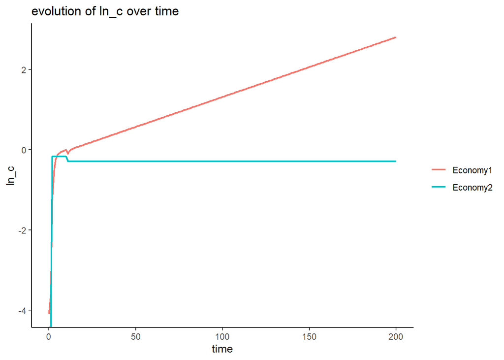

```r
#visualization

ggplot()+
  geom_line(data = economy1_df, aes(x = as.numeric(row.names(economy1_df)), y = ln_c, color = "Economy1"), size = 0.75)+
  geom_line(data = economy2_df, aes(x = as.numeric(row.names(economy1_df)), y = ln_c, color = "Economy2"), size = 0.75)+
  labs(title = "evolution of ln_c over time", x = "time", color = NULL)+
  theme_classic()
```

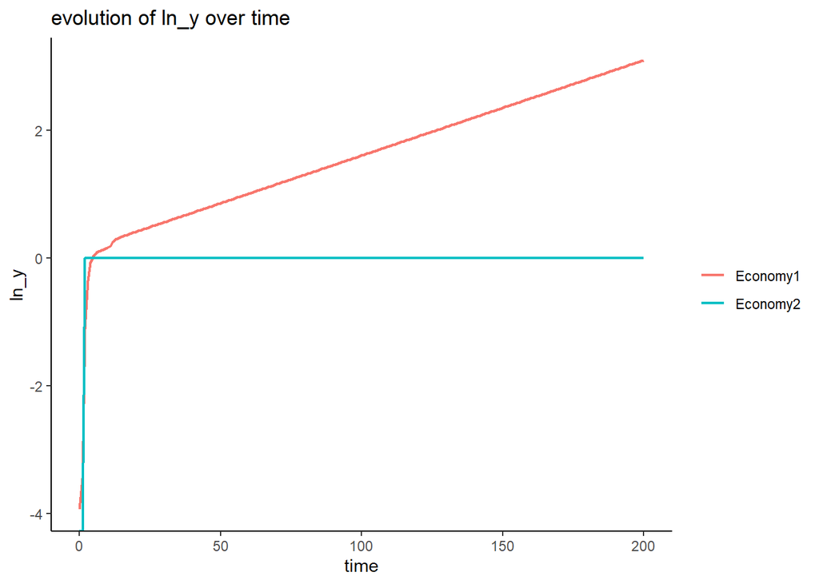

```r
#visualization
ggplot()+
  geom_line(data = economy1_df, aes(x = as.numeric(row.names(economy1_df)), y = ln_y, color = "Economy1"), size = 0.75)+
  geom_line(data = economy2_df, aes(x = as.numeric(row.names(economy1_df)), y = ln_y, color = "Economy2"), size = 0.75)+
  labs(title = "evolution of ln_y over time", x = "time", color = NULL)+
  theme_classic()
```

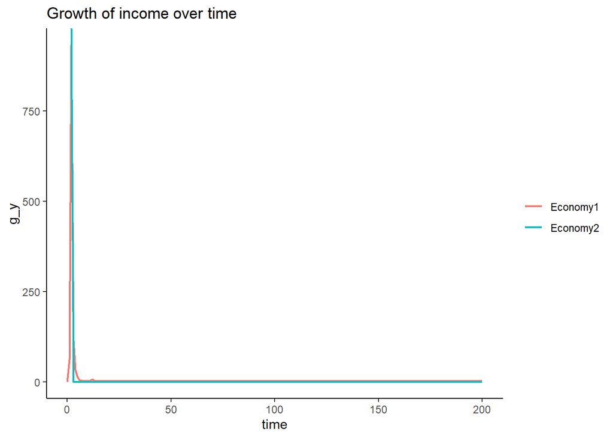

```r
#visualization
ggplot()+
  geom_line(data = economy1_df, aes(x = as.numeric(row.names(economy1_df)), y = g_y, color = "Economy1"), size = 0.75)+
  geom_line(data = economy2_df, aes(x = as.numeric(row.names(economy1_df)), y = g_y, color = "Economy2"), size = 0.75)+
  labs(title = "Growth of income over time", x = "time", color = NULL)+
  theme_classic()
```

### Exercise 4.1.g

### Exercise 4.1.h

### Exercise 4.2

### Exercise 4.2.a

### Exercise 4.2.b

### Exercise 4.2.c

### Exercise 4.2.d

### Exercise 4.2.e

```r
a <- list(a = 1:100, b = 1:100)
class(a) <- "data.frame"
```